# Steve Instructor Support Group Data

### **September 25, 2019 to October 09, 2019**

### Session 7

#### **At the end of today’s session, I CAN: Recall the definition of marketing and practices applying the S.A.V.E. framework to my business’ products and or services.**

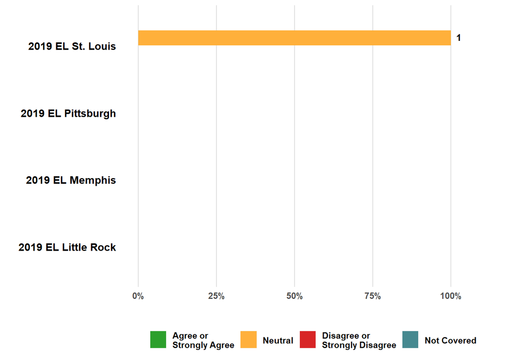

#### **At the end of today’s session, I CAN: Understand the value of my product/service in comparison to my competitors.**

#### **At the end of today’s session, I CAN: Understand my current customers’ perception of my product/service.**

#### **I completed my session prep (e.g. readings, worksheets).**

#### **The instructor effectively managed today’s session agenda (e.g., good time management, covered whole agenda, good facilitation).**

### Session 8

#### **At the end of today’s session, I CAN: Identify my target market(s) and develop a market segmentation strategy.**

#### **At the end of today’s session, I CAN: Identify my ideal customer(s) and develop an ideal customer profile.**

#### **At the end of today’s session, I CAN: Assess the costs and benefits associated with retaining existing customers versus acquiring new customers.**

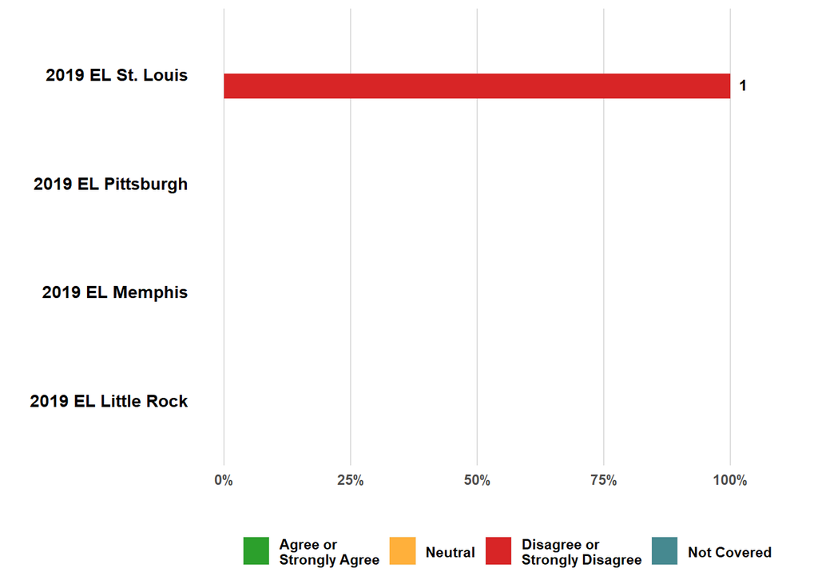

#### **I completed my session prep (e.g. readings, worksheets).**

#### **The instructor effectively managed today’s session agenda (e.g., good time management, covered whole agenda, good facilitation).**

### Session 9

#### **At the end of today’s session, I CAN: Identify social media tools that could move prospects through the sales pipeline.**

#### **At the end of today’s session, I CAN: Understand the stages of the sales cycle and develop strategies for growing my sales pipeline by increasing my win rate and by decreasing the length of my sales cycle.**

#### **At the end of today’s session, I CAN: Identify blockages in my sales pipeline and develop specific strategies for addressing them.**

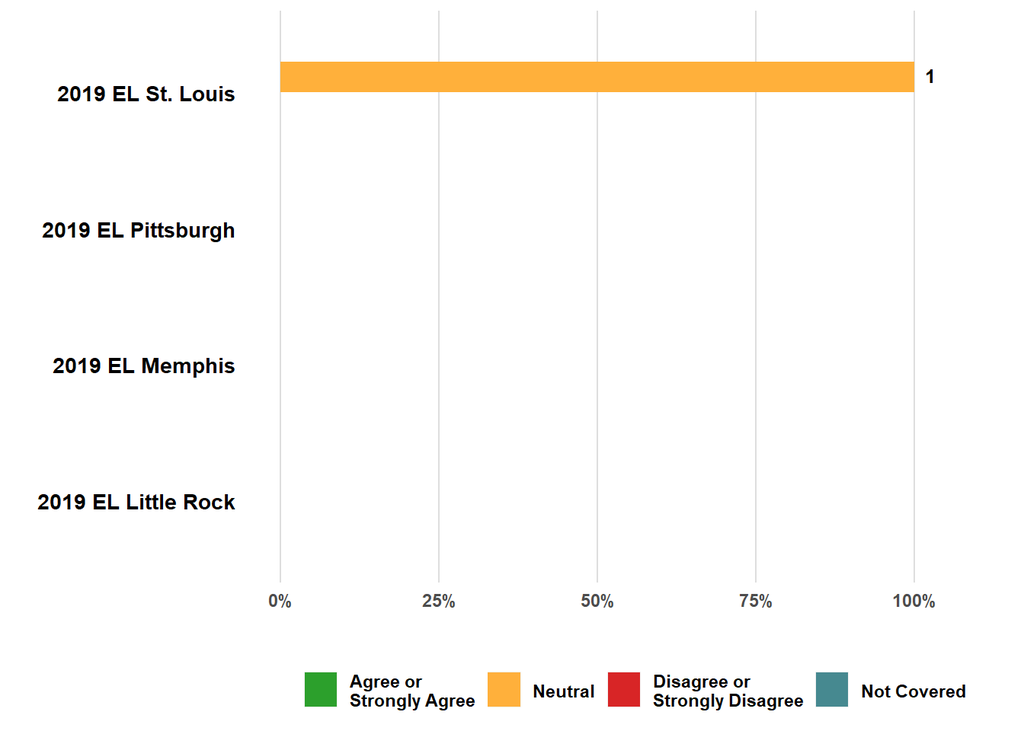

#### **I completed my session prep (e.g. readings, worksheets).**

#### **The instructor effectively managed today’s session agenda (e.g., good time management, covered whole agenda, good facilitation).**

### Session 10

#### **At the end of today’s session, I CAN: Identify the employees and managers needed to grow my business over the next 3 years.**

#### **At the end of today’s session, I CAN: Assess my leadership strengths and readiness to hire additional talent.**

#### **At the end of today’s session, I CAN: Identify motivational factors that contribute to a high performance culture.**

#### **I completed my session prep (e.g. readings, worksheets).**

#### **The instructor effectively managed today’s session agenda (e.g., good time management, covered whole agenda, good facilitation).**

### Session 12

#### **At the end of today’s session, I CAN: Determine what types of contracting are appropriate for my business now.**

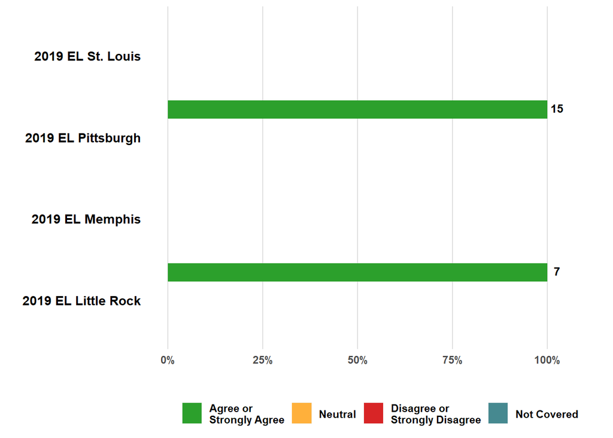

#### **At the end of today’s session, I CAN: Ascertain my readiness to secure contracts successfully and what resources exist to help me be successful.**

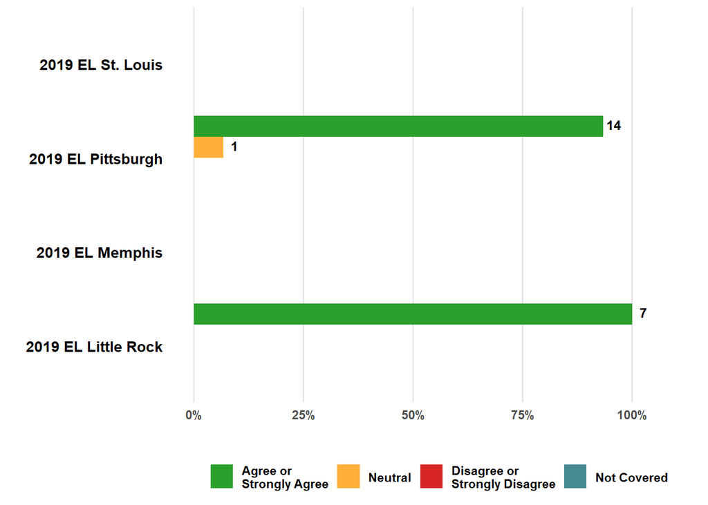

#### **At the end of today’s session, I CAN: Understand the steps and costs associated with successfully securing contracts with anchor institutions and with local, state, and federal government.**

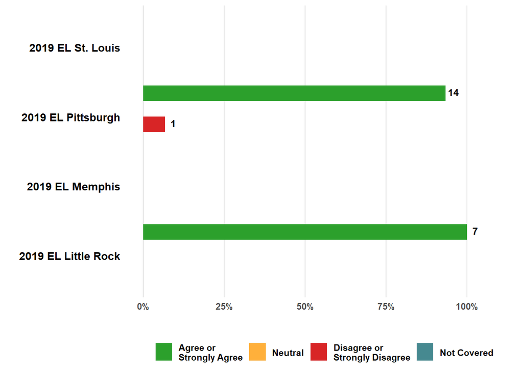

#### **I completed my session prep (e.g. readings, worksheets).**

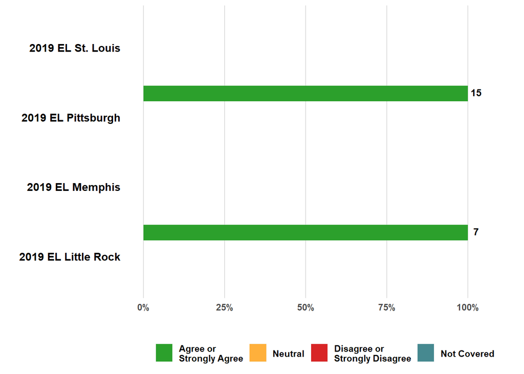

#### **The instructor effectively managed today’s session agenda (e.g., good time management, covered whole agenda, good facilitation).**

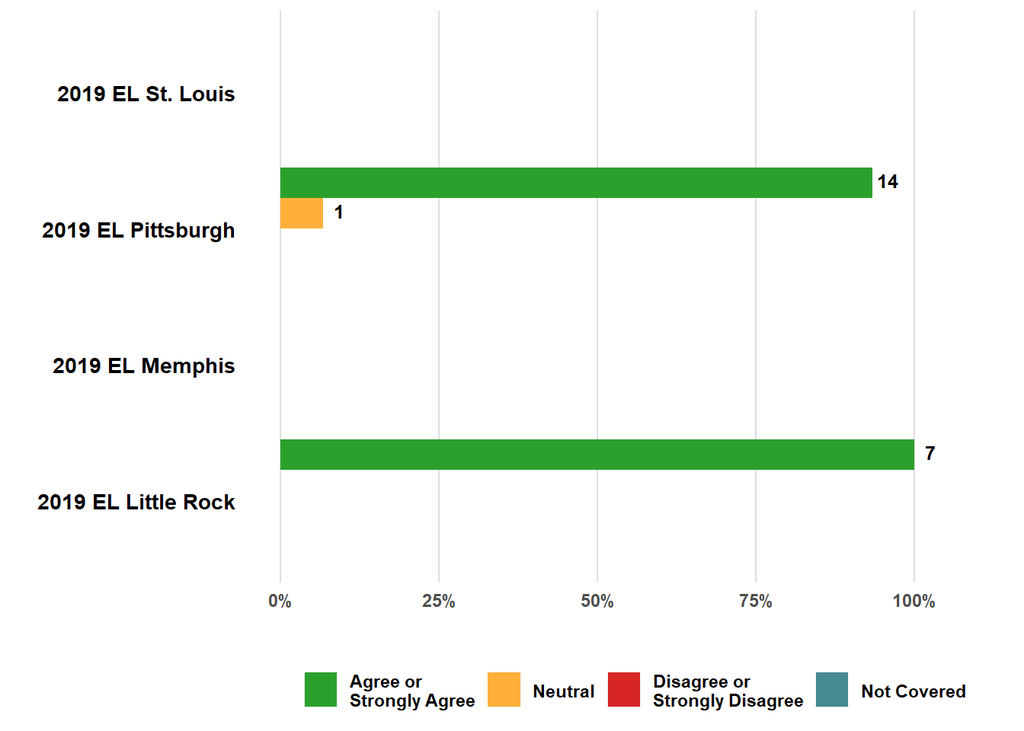